# Communicate Data Findings in PISA 2012

by Philipp Lutz

# Introduction

In this analysis, we look at data from the 2012 PISA study to gain insights into the academic performance of students worldwide. Particular attention is paid to the relationship between student performance and various socio-demographic factors. By analysing gender differences, socio-economic backgrounds and parental education levels, we open up a discussion about equality and educational opportunities. Our visualisations and analyses aim to create a deeper understanding of the distribution and determinants of student achievement.

# How are the total scores distributed by countries?

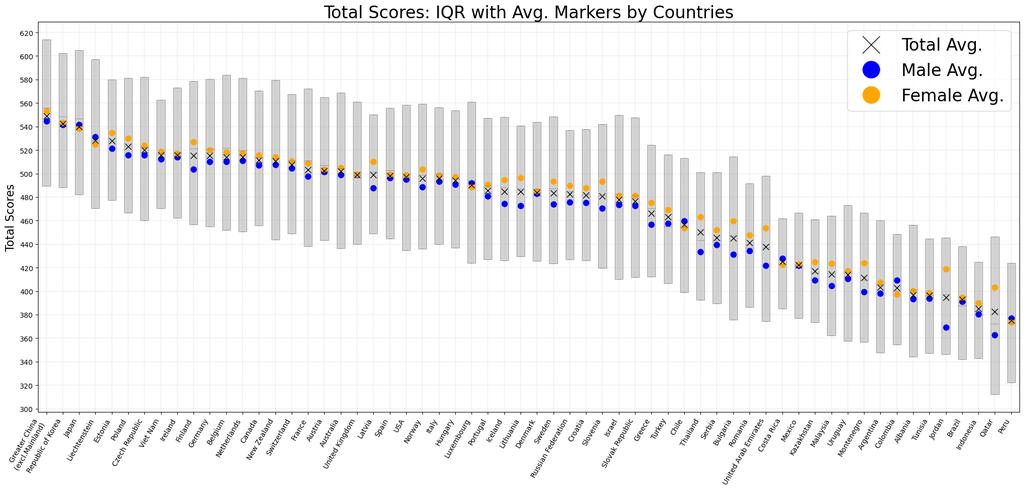

# How are the total scores distributed by gender?

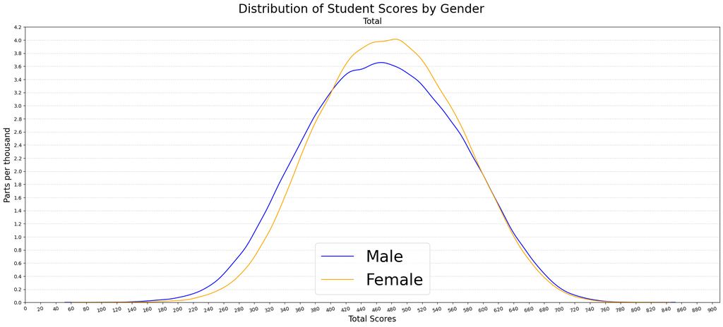

The distribution of total scores, broken down by gender, shows that male students generally have lower scores, but are more frequently represented in the higher scores than female students. The distributions of both genders appear normally distributed, indicating that there are no extreme deviations from a bell curve typical of many biological and social processes.

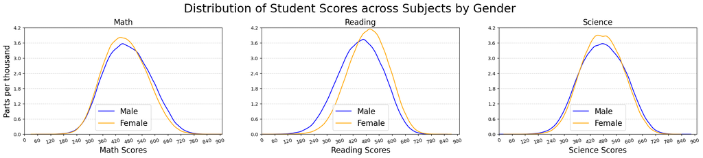

These three diagrams show the distribution of scores in maths, reading and science, each broken down by gender. In maths, male pupils appear to perform slightly better, while female pupils are in the lead in reading. In science, the performance of both genders is very similar. These patterns may indicate specific educational trends or cultural influences.

# What is the relationship between the Scores and the parental factors?

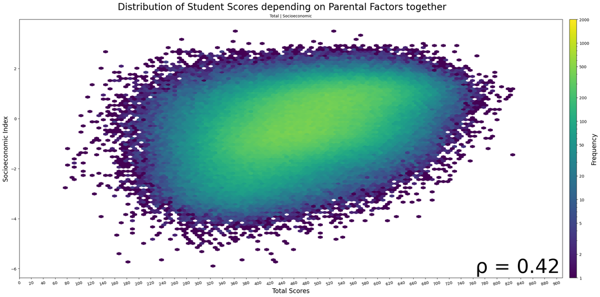

In the hexbin chart, which shows the relationship between students' overall scores and the socioeconomic index, some outliers can be seen despite the overall positive correlation. These could indicate unique circumstances or resilience to socioeconomic disadvantage.

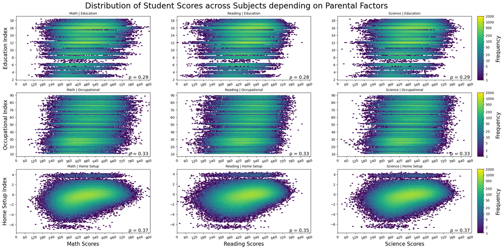

The last three pairs of hexbin diagrams examine the relationship between students' scores in maths, reading and science and various parental factors: Education, Occupation and Home Environment. The correlation coefficients vary by subject and parental factor, but they all show a positive correlation, suggesting that parental factors have an impact on academic achievement.

# Conclusion